# Prediction Assignment Writeup

Jeet Bhadouria

2025-11-09

# Abstract

The goal of this assignment is to predict the behaviour of the enthusiasts using devices such as Jawbone Up, Nike FuelBand, and Fitbit it is now possible to collect a large amount of data about personal activity relatively inexpensively. Using the tools that we’ve learnt about mashine learning and various models we need to prepare and find the best model to achive the assignment objective.

### Data Source:

*The training data for this project are available here:*

[Training Data](https://d396qusza40orc.cloudfront.net/predmachlearn/pml-training.csv)

*The test data are available here:*

[Testing Data](https://d396qusza40orc.cloudfront.net/predmachlearn/pml-testing.csv)

**Required Libraries**

```r
#required libraries for our analysis
require(rpart)
require(gbm)
require(rattle)
require(randomForest)
require(caret)
require(here)
```

### Loading Data

```r
pml_training<- read.csv(here("pml-training.csv"))
```

*Diving into data*

```r
#dimensions of our data
dim(pml_training)
```

```
## [1] 19622   160
```

```r
#structure of data
str(pml_training)
```

```r
#variables of the data
names(pml_training)
```

### Polishing Data

Our first step is to remove the columns that are unnecessary to our models and we can catch them by just little exploration that we did…

```r
data<- pml_training[,-(1:5)]
```

Now filtering out the variables that have negligible effect in improving our models.

```r
#zero variance columns
ext_col<-nearZeroVar(data)
data<- data[,-ext_col]
#removing columns which have more than the avg NA of 70%
rem_na<- sapply(data, function(x) mean(is.na(x))>0.7)
clean_data<- data[,rem_na == FALSE]
```

*Data Slicing*

To find the best model we need to take a piece of our training data for validation.

```r
slice<- createDataPartition(clean_data$classe, p = 0.7, list = FALSE)
training<- clean_data[slice,]
val_data<- clean_data[-slice,]
# setting parameter
set.seed(122)
control<- trainControl(method = "cv", number = 5)
```

# Model Testing

### 1. Gradient Boosting

```r
#gradient boosting  modelling(gbm)
set.seed(123)
gbm_model<- train(form = classe ~ .,
                  data = training,
                  method = "gbm",
                  trControl = control)
```

- *Visual Insights*

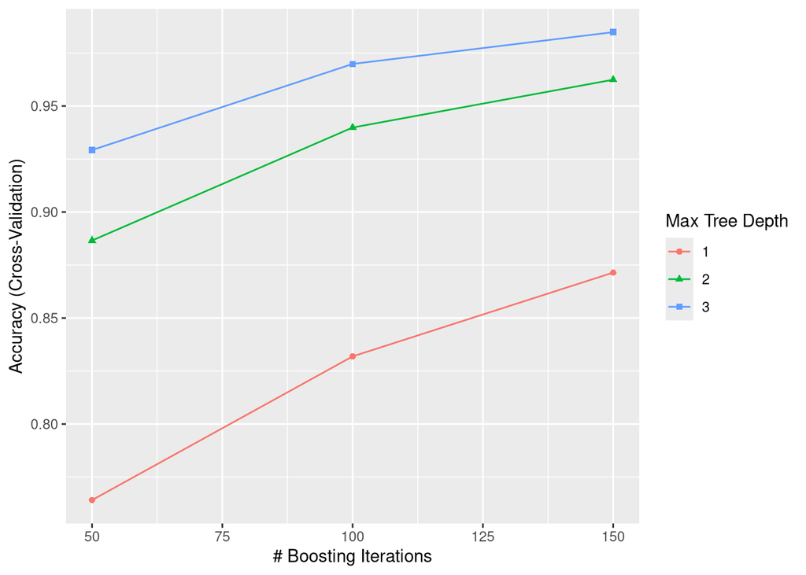

- *Model Validation*

```r
#validation
pre_gbm<- predict(gbm_model, val_data)
confusionMatrix(table(pre_gbm, val_data$classe))
```

```
## Confusion Matrix and Statistics
##
##
## pre_gbm    A    B    C    D    E
##       A 1673   13    0    0    0
##       B    1 1112   14    2    1
##       C    0   13 1008   15    4
##       D    0    1    4  947    6
##       E    0    0    0    0 1071
##
## Overall Statistics
##
##                Accuracy : 0.9874
##                  95% CI : (0.9842, 0.9901)
##     No Information Rate : 0.2845
##     P-Value [Acc > NIR] : < 2.2e-16
##
##                   Kappa : 0.9841
##
##  Mcnemar's Test P-Value : NA
##
## Statistics by Class:
##
##                      Class: A Class: B Class: C Class: D Class: E
## Sensitivity            0.9994   0.9763   0.9825   0.9824   0.9898
## Specificity            0.9969   0.9962   0.9934   0.9978   1.0000
## Pos Pred Value         0.9923   0.9841   0.9692   0.9885   1.0000
## Neg Pred Value         0.9998   0.9943   0.9963   0.9965   0.9977
## Prevalence             0.2845   0.1935   0.1743   0.1638   0.1839
## Detection Rate         0.2843   0.1890   0.1713   0.1609   0.1820
## Detection Prevalence   0.2865   0.1920   0.1767   0.1628   0.1820
## Balanced Accuracy      0.9982   0.9863   0.9879   0.9901   0.9949
```

### 2. Decision Tree

```r
#decision tree
set.seed(124)
dec_model<- rpart(formula = classe ~ .,
                  data = training,
                  method = "class")
```

*Tuning the plot for a insightful fit.*

```r
#plot tuning
printcp(dec_model)
pruned_mod<- prune(dec_model, cp = 0.065)
```

- *Visual Insights*

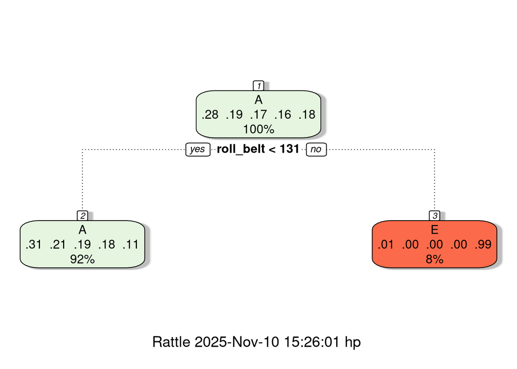

- *Model Validation*

```r
# testing
pre_dec<- predict(dec_model, val_data, type = "class")
dec_valmat<- confusionMatrix(table(pre_dec, val_data$classe))
```

### 3. Random Forest

```r
set.seed(125)
rf_model <- train(
  classe ~ .,
  data = training,
  method = "rf",
  trControl = control)
```

- *Visual Insights*

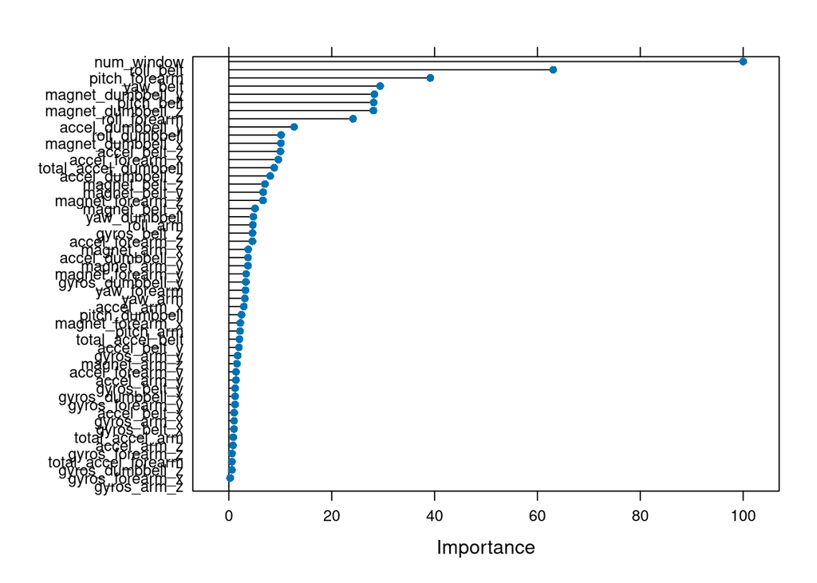

```r
#plot
plot(varImp(rf_model))
```

- *Model Validation*

```r
#validation
pre_rf<- predict(rf_model, val_data)
confusionMatrix(table(pre_rf, val_data$classe))
```

```
## Confusion Matrix and Statistics
##
##
## pre_rf    A    B    C    D    E
##      A 1674    5    0    0    0
##      B    0 1133    3    0    0
##      C    0    1 1023    4    0
##      D    0    0    0  960    2
##      E    0    0    0    0 1080
##
## Overall Statistics
##
##                Accuracy : 0.9975
##                  95% CI : (0.9958, 0.9986)
##     No Information Rate : 0.2845
##     P-Value [Acc > NIR] : < 2.2e-16
##
##                   Kappa : 0.9968
##
##  Mcnemar's Test P-Value : NA
##
## Statistics by Class:
##
##                      Class: A Class: B Class: C Class: D Class: E
## Sensitivity            1.0000   0.9947   0.9971   0.9959   0.9982
## Specificity            0.9988   0.9994   0.9990   0.9996   1.0000
## Pos Pred Value         0.9970   0.9974   0.9951   0.9979   1.0000
## Neg Pred Value         1.0000   0.9987   0.9994   0.9992   0.9996
## Prevalence             0.2845   0.1935   0.1743   0.1638   0.1839
## Detection Rate         0.2845   0.1925   0.1738   0.1631   0.1835
## Detection Prevalence   0.2853   0.1930   0.1747   0.1635   0.1835
## Balanced Accuracy      0.9994   0.9971   0.9980   0.9977   0.9991
```

# The Best Fit

*Now let’s fit our model with best accuracy to the test dataset*

```r
pre_test<- predict(rf_model, pml_testing)#fitting random forest model
pre_test
```

```
##  [1] B A B A A E D B A A B C B A E E A B B B
## Levels: A B C D E
```